# Fatalities from Attacks on Civilians Before vs. After South Darfur UN Base Closures - Visual 8

Rob Boswell

7-27-2023

- Previous Page
- Next Page

#### In each of the visuals below, I have created 50 mi radius buffers around all UN bases that were withdrawn in South Darfur in 2017, 2018, and 2019. After 2019, no more bases were withdrawn from South Darfur. As with West Darfur in Visual 7, I have also calculated the total attacks on civilians and fatalities from such attacks inside these buffers and plotted them in a heat map table further below for analysis.

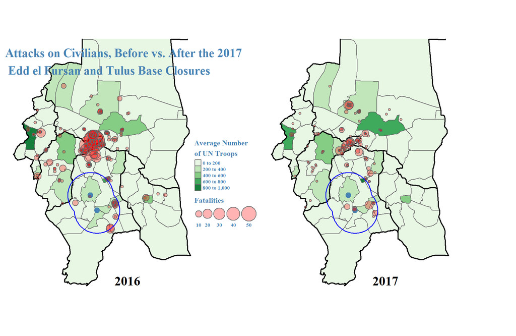

#### Looking at the 2017 vs. 2018 maps below, whereas in 2017 (the year before the Buram and Graida UN compounds were closed) there were 32 attacks on civilians and 28 fatalities within a 50 mi radius of these bases, in 2018 there were 27 attacks and 28 fatalities - roughly the same level of violence. A caveat should be noted: it appears from the map that although troops were withdrawn from the Buram and Graida UN bases in 2018, there were actually more UN troops within the buffer in 2018 than in 2017. This is likely a result of transfering troops from the closed bases to other nearby bases that were still active.

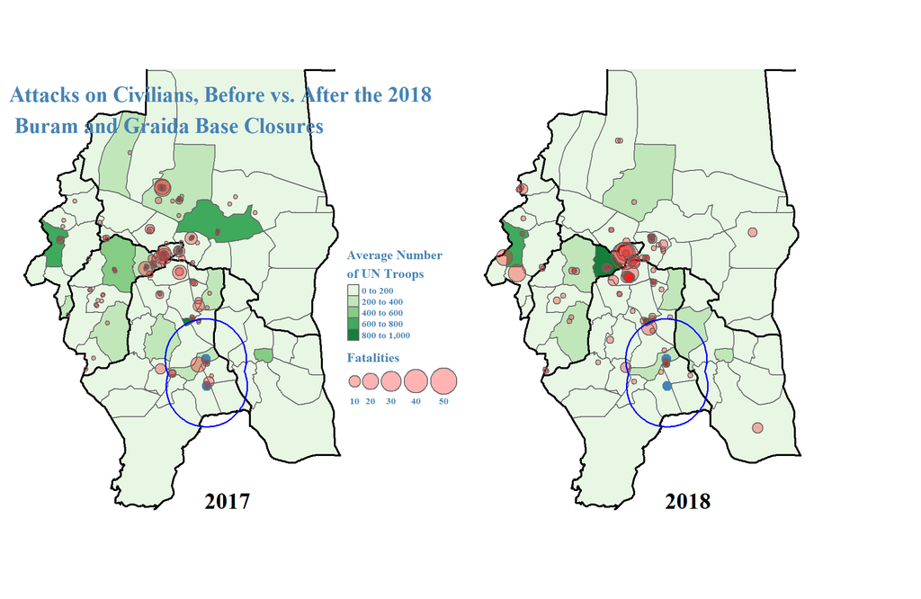

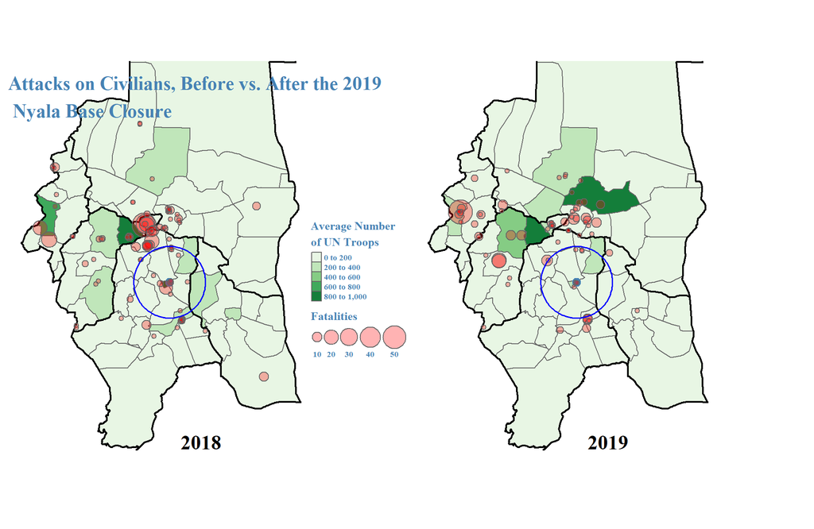

#### However, just as with the spikes in West Darfur violence in 2019 and 2021 following UN base withdrawals, the power vacuum from years of UN base withdrawals is likely only one of several factors which led to the increase in violence in South Darfur. [Such factors which have been cited include intercommunal violence in retaliation for tribal cattle raiding](https://reliefweb.int/report/sudan/30-people-killed-intercommunal-violence-south-darfur) and [land disputes between displaced land owners and those occupying their land](https://www.aljazeera.com/news/2020/7/26/sudan-to-deploy-troops-to-darfur-after-killings-pm-hamdok).

|  | Area around 2017 Closed Bases Attacks | Area around 2017 Closed Bases Fatalities | Area around 2018 Closed Bases Attacks | Area around 2018 Closed Bases Fatalities | Area around 2019 Closed Bases Attacks | Area around 2019 Closed Bases Fatalities |
| --- | --- | --- | --- | --- | --- | --- |
| 2016 | 47 | 58 | 47 | 55 | 48 | 27 |
| 2017 | 25 | 31 | 32 | 28 | 35 | 22 |
| 2018 | 32 | 37 | 27 | 28 | 21 | 22 |
| 2019 | 11 | 16 | 13 | 16 | 10 | 6 |
| 2020 | 12 | 57 | 16 | 78 | 10 | 31 |
| 2021 | 18 | 33 | 26 | 45 | 18 | 17 |

#### In Visual 9, to better understand the causes of the violence against civilians, and especially in 2019 and 2021 in West Darfur and in 2020 and 2021 in South Darfur, I will examine trends in the types of perpetrators found resposible for attacks on civilians between 2016-2021.

- Previous Page
- Next Page